# Tracking Loggerhead Turtle Carapace Length

UCSF PROPEL Programming and Statistics Spring 2025 Final Project

Belle Lomeli, Rhiannon Red Bird, Cristy Mendoza, Adriana Bibo

We are going to analyze a data set from the Southeast Fisheries Science Center, which analyzed skeletal growth marks in humerus bones of 222 juvenile loggerhead sea turtles (Caretta caretta) stranded dead along the Atlantic US coast. We’ll parse through the raw data, then perform a descriptive and inferential statistical analysis on it.

## Section 1: Loading the Data

```r
#First, we'll load in our libraries
library(tidyverse)
library(ggprism)
library(ggplot2)
```

```r
#Next, we'll check out the raw data and remove any unknown variables particularly from the sex column

loggerhead_data <- read_csv("Loggerhead_oceanic_stage_duration.csv", show_col_types = FALSE)

loggerhead_df <- loggerhead_data %>%
  mutate(Sex = ifelse(Sex == "unknown", NA, Sex)) %>%
  drop_na()
```

We can preview our cleaned up data set below.

```r
head(loggerhead_df)
```

```
## # A tibble: 6 × 7
##   Turtle_ID State Sex   Straight_Carapace_Length Growth   Age  Year
##       <dbl> <chr> <chr>                    <dbl>  <dbl> <dbl> <dbl>
## 1        13 SC    male                      27.6    2.3  3.75  2001
## 2        13 SC    male                      30.8    4.1  4.75  2002
## 3        13 SC    male                      33.9    2.1  5.75  2003
## 4        13 SC    male                      36.8    3.8  6.75  2004
## 5        13 SC    male                      39.6    1.7  7.75  2005
## 6        13 SC    male                      41.7    2.6  8.75  2006
```

## Section 2: Descriptive Statistics of Loggerhead Turtles

We’ll start by plotting the data in a boxplot comparing carapace length between male and female loggerhead turtles. Descriptive statistics only describe our data set, so we should not draw any correlative conclusions based on this initial test.

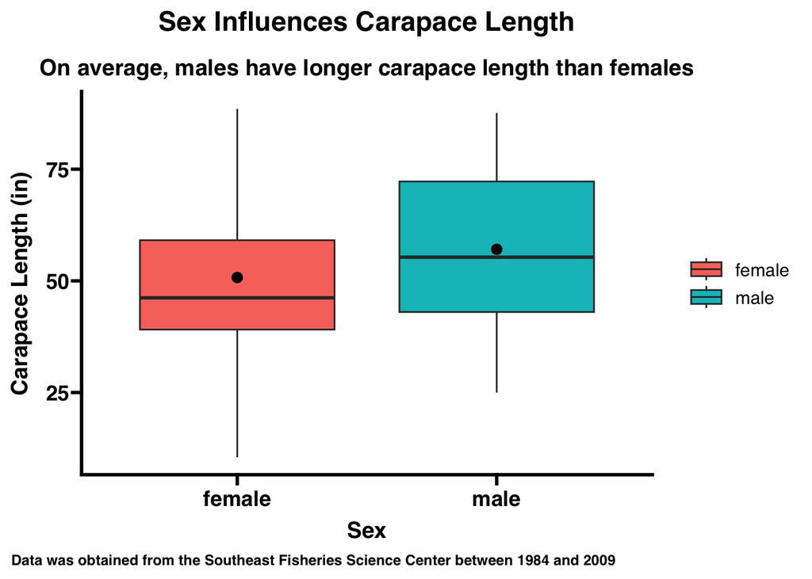

```r
loggerhead_df %>%
    ggplot() +
  geom_boxplot(mapping = aes(x = Sex , y = Straight_Carapace_Length, fill = Sex)) +
  theme_prism() +
  labs(
    title = "Sex Influences Carapace Length",
    subtitle = "On average, males have longer carapace length than females",
    caption = "Data was obtained from the Southeast Fisheries Science Center between 1984 and 2009",
    x = "Sex",
    y = "Carapace Length (in)"
  ) +
  stat_summary(mapping = aes(x = Sex , y = Straight_Carapace_Length),
    fun = "mean"
  ) +
 theme(
    plot.caption = element_text(hjust = 0, size = 9),
    plot.caption.position = "plot"
  )
```

We can create a table of the descriptive statistics plotted on our graph as well.

```r
descriptive_stats <- loggerhead_df %>%
  group_by(Sex) %>%
  summarise(
    mean_length = mean(Straight_Carapace_Length),
    median_length = median(Straight_Carapace_Length),
    min_length = min(Straight_Carapace_Length),
    max_length = max(Straight_Carapace_Length),
    sd_length = sd(Straight_Carapace_Length)
  )

print(descriptive_stats)
```

```
## # A tibble: 2 × 6
##   Sex    mean_length median_length min_length max_length sd_length
##   <chr>        <dbl>         <dbl>      <dbl>      <dbl>     <dbl>
## 1 female        50.8          46.2       10.5       88.5      16.2
## 2 male          57.1          55.3       25         87.6      16.3
```

### Checking Normality of The Data

Before running any significance tests, we should check the normality of our variables to determine if the data is parametric or non-parametric. This can help us apply the proper testing method to our data.

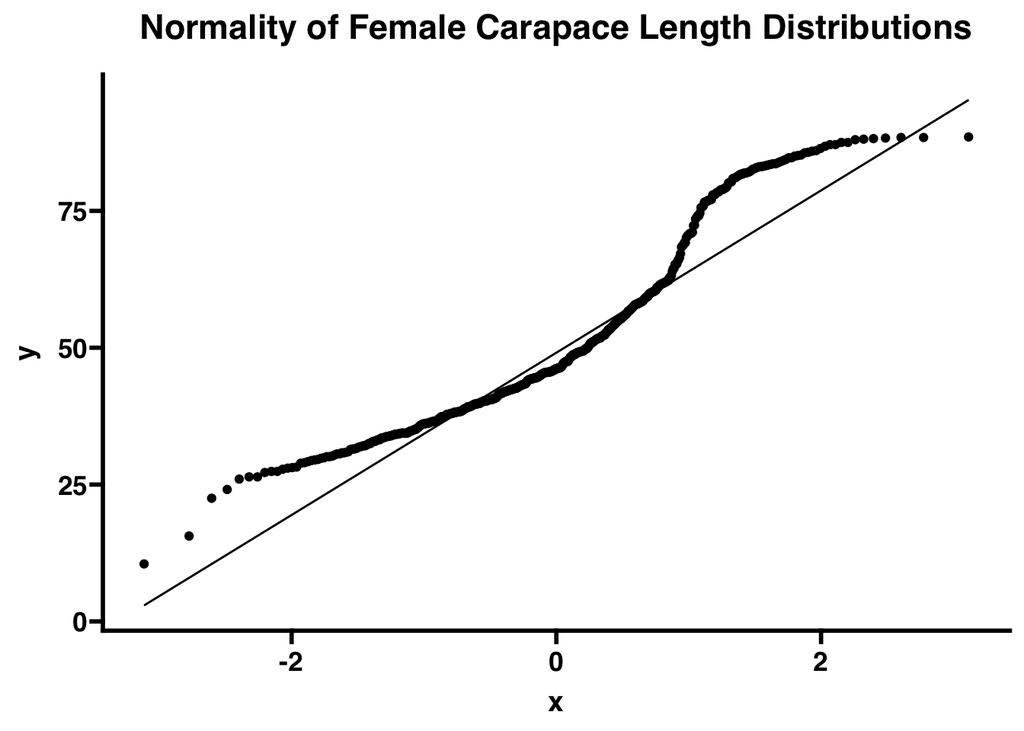

```r
loggerhead_df %>%
  filter(Sex == "female") %>%
  ggplot() +
  geom_qq( mapping = aes(sample = Straight_Carapace_Length)) +
  geom_qq_line(mapping = aes(sample = Straight_Carapace_Length)) +
  theme_prism() +
  labs(
    title = "Normality of Female Carapace Length Distributions"
  )
```

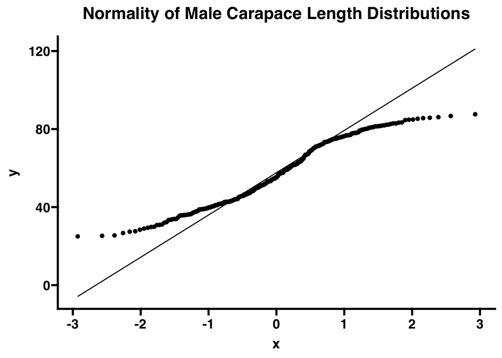

```r
loggerhead_df %>%
  filter(Sex == "male") %>%
  ggplot() +
  geom_qq( mapping = aes(sample = Straight_Carapace_Length)) +
  geom_qq_line(mapping = aes(sample = Straight_Carapace_Length)) +
  theme_prism() +
  labs(
    title = "Normality of Male Carapace Length Distributions"
  )
```

Since our data skews from the linear slope at the far end points, we can conclude it is not normal and should perform a nonparametric test, such as the Wilcox test, to determine if there is a significant difference in mean carapace length between the sexes of Loggerhead turtles.

### Wilcox Test

Our null hypothesis would be that there is no significant carapace length difference between sexes in our data, and we can us a p value of 0.05 as our cut off point for significance.

```r
F_length <- loggerhead_df  %>% filter(Sex == "female") %>% pull(Straight_Carapace_Length)
M_length <- loggerhead_df %>% filter(Sex == "male") %>% pull(Straight_Carapace_Length)
wilcox.test(F_length, M_length)
```

```
##
##  Wilcoxon rank sum test with continuity correction
##
## data:  F_length and M_length
## W = 61719, p-value = 5.913e-08
## alternative hypothesis: true location shift is not equal to 0
```

Based on this analysis, we can reject the null hypothesis and conclude that there is a significant difference in carapace length between male and female Loggerhead turtles in this data set.

## Sections 3: Inferential Statistics of Loggerhead Turtles

Inferential statistics can be a useful method of drawing conclusions for a whole population based on a select sample, such as drawing conclusions about the Loggerhead species based on the turtles surveyed in this data set. We can estimate population parameters, such as whether carapace length is different between sexes in the total Loggerhead population, and determine our confidence of this conclusion.

### Bootstrapping to Determine Confidence Interval and Standard Error of the Data

#### Resampling

For every resample, we take the mean carapace length of females and subtract it from the mean carapace length of males.

```r
#Creates an empty vector to store our bootstrapping
hundred_resamples <- c()


for(i in 1:100){
  oneresample <- loggerhead_df %>%
    sample_n(size=333, replace = TRUE) #For every resample, sample 333 rows randomly to mimic random sampling variation

 sc_length <- oneresample %>%
  group_by(Sex) %>%
  summarize(mean_length = mean(Straight_Carapace_Length)) #Group by sex and take the average of carapace length per resample

test_stat <- sc_length %>%
  filter(Sex == "male") %>%
  pull(mean_length) -
  sc_length %>%
  filter(Sex == "female") %>%
  pull(mean_length) #Subtract average female carapace length from average male carapace length

hundred_resamples <- hundred_resamples %>% rbind(test_stat) #Store the test statistic from each resample into our vector
}

hundred_resamples <- enframe(hundred_resamples) #Convert the vector into a data frame
```

Next, we’ll find the standard error.

```r
SE <- hundred_resamples %>% pull(value) %>% sd()
SE
```

```
## [1] 1.71539
```

This point estimate is the average of lengths between sexes, estimating the true difference in length of the population.

```r
summary_turtles <- loggerhead_df %>%
  group_by(Sex) %>%
  summarise(mean_length = mean(Straight_Carapace_Length))
PE <- summary_turtles %>%
  filter(Sex == "male") %>% pull(mean_length) -
  summary_turtles %>%
  filter(Sex == "female") %>% pull(mean_length)

PE
```

```
## [1] 6.302078
```

The confidence interval is the range of plausible differences in length between male and female loggerheads.

```r
lower_bound_CI <- PE - (1.96 * SE)
upper_bound_CI <- PE + (1.96 * SE)

lower_bound_CI
```

```
## [1] 2.939915
```

```r
upper_bound_CI
```

```
## [1] 9.664242
```

Finally, we’ll plot our bootstrapped resamples, confidence interval, and point estimate.

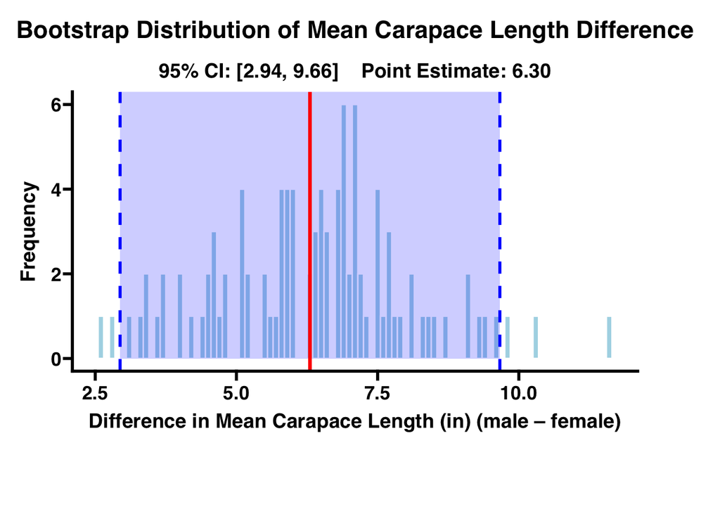

```r
ggplot(hundred_resamples, aes(x = value)) +
  geom_histogram(binwidth = 0.1, fill = "lightblue", color = "white") +
  # shaded CI region
  annotate("rect",
           xmin = lower_bound_CI, xmax = upper_bound_CI,
           ymin = 0,            ymax = Inf,
           alpha = 0.2,         fill = "blue") +
  # dashed lines at the CI bounds
  geom_vline(xintercept = lower_bound_CI, linetype = "dashed", color = "blue", linewidth = 1) +
  geom_vline(xintercept = upper_bound_CI, linetype = "dashed", color = "blue", linewidth = 1) +
  # solid line at the point estimate
  geom_vline(xintercept = PE, color = "red", linewidth = 1.2) +
  theme_prism() +
  labs(
    title =  "Bootstrap Distribution of Mean Carapace Length Difference",
    subtitle = sprintf("95%% CI: [%.2f, %.2f]    Point Estimate: %.2f",
                       lower_bound_CI, upper_bound_CI, PE),
    x = "Difference in Mean Carapace Length (in) (male – female)",
    y = "Frequency"
  ) +
  theme(
    plot.margin = unit(c(1, 4, 4, 1), "lines"),
  )
```

## Bibliography

Southeast Fisheries Science Center, 2025: Loggerhead oceanic stage duration in North Atlantic Ocean from 1984 to 2009 (NCEI Accession 0157929), https://www.fisheries.noaa.gov/inport/item/29718.